DS 3001: Foundations of Machine Learning

# The Bootstrap

[figure not shown]

## Previously

- Last time, the sample average changed from one sample to the next.
  - A **sample** is a group of observations: $[3,7,2,9,5]$ is one sample of size 5.
- A **statistic** is a number calculated from a sample, such as its mean.
- The **sampling distribution** shows how often a statistic takes different values across samples of the same size from one population.

How can we estimate that variation when we have only one observed sample?

## Cumulative Distribution Function

Let $D$ be the sum of two independent fair dice. Its **cumulative distribution function (CDF)** gives the probability of a value at or below $x$:
$$F(x)=P(D\le x).$$

For example, 21 of the 36 equally likely dice pairs have a sum at most 7:
$$F(7)=\frac{21}{36}\approx0.583.$$

As $x$ increases, the CDF cannot decrease. Its values lie between 0 and 1.

## The Empirical Distribution

The **empirical distribution** approximates the population distribution using the observed sample. Each of the $n$ observations receives probability $1/n$.

Example: five observed dice sums, so $n=5$.

| Observed value | 3 | 7 | 2 | 9 | 5 |
| --- | --- | --- | --- | --- | --- |
| Probability | $1/5$ | $1/5$ | $1/5$ | $1/5$ | $1/5$ |

Adding probabilities at or below a cutoff gives the **empirical CDF**.

## Empirical Cumulative Distribution Function

The **empirical CDF (ECDF)** estimates a population CDF using $n$ observed values. At any cutoff $x$, it gives the sample proportion
$$F_n(x)=\frac{\text{number of observations at or below }x}{n}.$$

For the same five dice sums:

| Cutoff $x$ | Observations at or below $x$ | $F_5(x)$ |
| --- | --- | --- |
| 5 | 3, 2, 5 | $3/5=0.6$ |
| 7 | 3, 7, 2, 5 | $4/5=0.8$ |

The sample proportion 0.6 estimates the population probability $P(D\le5)$.

## Estimating the Dice CDF

Compare the ECDF of 150 simulated dice sums with the known population CDF:

```python
rng_cdf = np.random.default_rng(8004)
dice_sums = rng_cdf.integers(1, 7, size=(150, 2)).sum(axis=1)
```

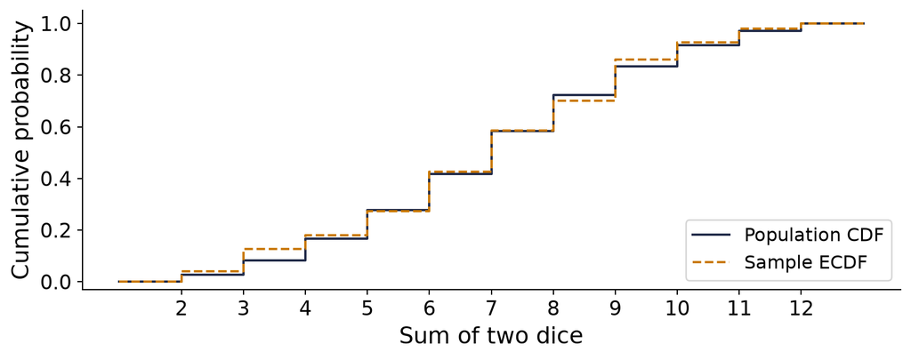

By the law of large numbers, the sample proportion approaches the population probability at each fixed cutoff as the sample grows.

## Why Bootstrap?

Sample: $[3,7,2,9,5]$, with mean $5.2$. How uncertain is this estimate of the population mean?

- In practice, we often cannot collect new data; we have to use the observed sample.
- The **bootstrap** mimics collecting data by resampling from the empirical distribution.
- Resamples can give different means.
- Repeated resampling **approximates the sampling variation** of the sample mean.

## Drawing a Bootstrap Sample

Start with $n$ observed values.

Assume they are **independent and identically distributed (iid)**: observations do not depend on one another and come from the same distribution.

1. Draw $n$ values independently **with replacement** from the $n$ observed values.
2. The drawn values form a **bootstrap sample**. Calculate its mean.

Repeating these steps estimates how much sample means vary across new samples.

## One Resample

Original sample: $[3,7,2,9,5]$, with mean
$$\bar x=\frac{3+7+2+9+5}{5}=5.2.$$

One bootstrap sample is $[7,7,2,9,3]$. What is its mean?

$$\bar x^*=\frac{7+7+2+9+3}{5}=5.6.$$

Each draw is made **with replacement**. The value 7 appears twice, and 5 is omitted.

## Several Resamples

Each resample has five observations.

| Sample | Observations | Mean |
| --- | --- | --- |
| Original | 3, 7, 2, 9, 5 | 5.2 |
| Resample 1 | 7, 7, 2, 9, 3 | 5.6 |
| Resample 2 | 2, 2, 3, 5, 7 | 3.8 |
| Resample 3 | 9, 9, 7, 5, 3 | 6.6 |

Each resample gives a value of the **sample mean**. Across many resamples, these values form the **bootstrap distribution**.

## Why Replacement Matters

What happens if we select all five observations **without replacement**?

- Their order can change, but the five values $[3,7,2,9,5]$ stay the same.
- Every resample mean would still be 5.2.
- Sampling with replacement changes how often observations appear, allowing the sample mean to vary.

## The Bootstrap Algorithm

Choose a statistic $S$, such as the sample mean, and a number of replications $R$.

1. Draw $n$ observations with replacement from the original sample of size $n$.
2. Calculate the statistic on that resample, $S_r^*$.
3. Repeat to obtain $S_1^*,\ldots,S_R^*$.

The spread of these values estimates how much the statistic varies across new samples.

## What Is Happening?

- New sample means vary around the **population mean**.
- Bootstrap means vary around the **observed sample mean**:
  - The observed sample mean takes the place of the population mean in resampling.

If the sample represents the population well, these two distributions should have similar shapes and spreads, even though their centers differ.

## Checking the Bootstrap

Consider a normal population with mean 0 and standard deviation 1.

Draw one sample of $n = 5{,}000$ independent observations:

```python
n = 5000
rng_data = np.random.default_rng(8006)
normal_sample = rng_data.normal(0, 1, size=n)
print("Sample mean:", round(normal_sample.mean(), 4))
```

```
Sample mean: 0.0119
```

How well does the bootstrap estimate variation in **sample means** across independent samples?

## Distribution of the Sample Mean

Generate 10,000 independent samples of size 5,000 from the normal population. Calculate one mean per sample.

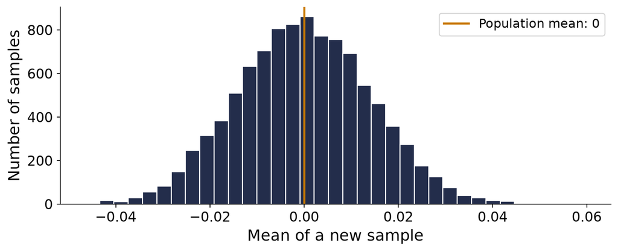

The standard deviation of these sample means is about 0.0142—the **standard error**.

## Bootstrapping the Sample Mean

Reuse `normal_sample`, generated on slide “Checking the Bootstrap.”

Draw $R = 10{,}000$ bootstrap resamples of $n = 5{,}000$ observations each, with replacement.

```python
R = 10000
rng_boot = np.random.default_rng(8008)
boot_means = []
for _ in range(R):
    resample = rng_boot.choice(normal_sample, size=n, replace=True)
    boot_means.append(resample.mean())
print("Bootstrap standard error:", round(np.std(boot_means), 4))
```

```
Bootstrap standard error: 0.0143
```

The bootstrap estimates a **standard error** of 0.0143, close to 0.0142 from independent population samples.

## Comparing Sampling Variation

Subtract the **population mean** (0) from each new sample mean and the **observed sample mean** (0.0119) from each bootstrap mean.

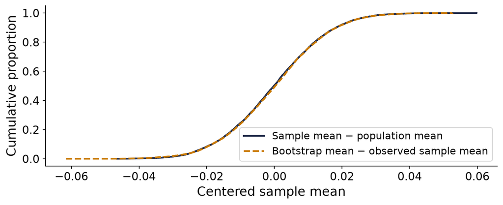

The centered distributions have similar shapes and spreads. The bootstrap approximates the sampling variation of the sample mean.

## The Central Limit Theorem

For large iid samples with finite population variance, the **distribution of the sample mean** is approximately normal, with
$$\text{mean }\mu
\qquad\text{and standard error }\frac{\sigma}{\sqrt n}.$$

Here, $\mu$ and $\sigma$ are the population mean and standard deviation.

In our normal-population example, $\sigma=1$ and $n=5{,}000$:

| Method | Standard error |
| --- | --- |
| Formula: $1/\sqrt{5{,}000}$ | 0.0141 |
| Independent samples from the population | 0.0142 |
| Bootstrap resamples of one sample | 0.0143 |

## Estimating Uncertainty

- A statistic can be easy to calculate even when a formula for its uncertainty is hard to obtain.
- The spread of bootstrap estimates measures sampling uncertainty.

Next, we will use bootstrap estimates to build a **confidence interval**: a range of plausible values for the population difference in survival rates.

## Example: Survival After Cardiac Arrest

Survival means discharge from hospital to home.

| Bystander CPR | Survived | Total | Survival rate |
| --- | --- | --- | --- |
| Received CPR | 19 | 662 | 2.87% |
| Did not receive CPR | 11 | 1,405 | 0.78% |

## Difference in Survival Rates

Subtract the survival rate without CPR from the rate with CPR:
$$\hat\delta=\frac{19}{662}-\frac{11}{1405}
\approx0.0209.$$

The observed survival rate was **2.09 percentage points higher** in the CPR group.

We will use the bootstrap to estimate the uncertainty in this difference.

## Representing Survival Outcomes

Create one array of patient outcomes for each group from the reported counts. Use **1 for survival** and **0 for non-survival**:

```python
with_cpr = np.r_[np.ones(19), np.zeros(643)]
without_cpr = np.r_[np.ones(11), np.zeros(1394)]
```

`np.r_` combines the ones and zeros into a single array.

Each array’s mean is the group’s observed survival rate.

## Bootstrapping the Rate Difference

- Resample with replacement within each group.
- Keep the group sizes at 662 and 1,405, respectively.
- Calculate the difference in survival rates.

```python
rng_cpr = np.random.default_rng(8002)
differences = []
for _ in range(5000):
    a = rng_cpr.choice(with_cpr, size=len(with_cpr), replace=True)
    b = rng_cpr.choice(without_cpr, size=len(without_cpr), replace=True)
    differences.append(a.mean() - b.mean())
```

`differences` contains 5,000 rate differences. Multiply by 100 to express them in percentage points.

## Distribution of Rate Differences

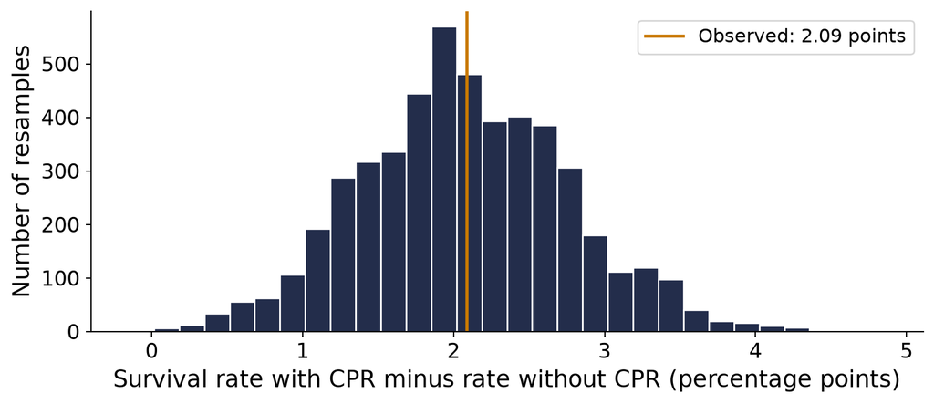

The bootstrap distribution is centered near 2.09 percentage points. Its spread estimates the uncertainty in the observed rate difference.

## Quantiles

The **$p$-quantile** is the value where the CDF first reaches or exceeds $p$.

For the median, start at $p=0.5$ and read the corresponding value on the horizontal axis.

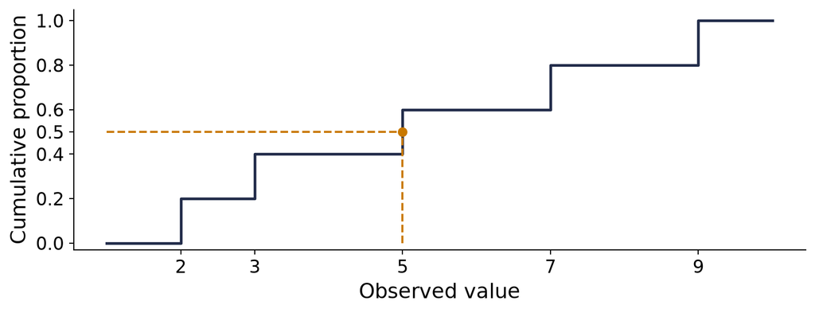

For [3, 7, 2, 9, 5], the 0.5 quantile (50th percentile, or median) is 5.

## Percentile Confidence Intervals

A **95% percentile bootstrap confidence interval** runs from the 2.5th to the 97.5th percentile of the bootstrap estimates.

For confidence level $c$, use the quantiles at
$$\frac{1-c}{2}\quad\text{and}\quad1-\frac{1-c}{2}.$$

For the CPR example, the interval estimates the population difference in survival rates.

## Interval for the Rate Difference

```python
cpr_interval = 100 * np.quantile(differences, [.025, .975])
print("95% interval (percentage points):", cpr_interval.round(2))
```

```
95% interval (percentage points): [0.75 3.46]
```

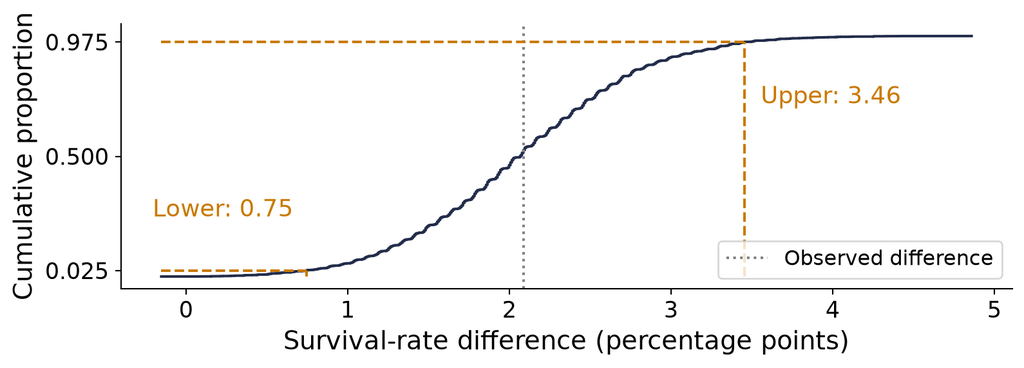

The estimated difference is 2.09 percentage points; the bootstrap 95% interval runs from 0.75 to 3.46 points.

## Interpreting the CPR Interval

**Data:**

Patient survival outcomes, grouped by CPR status.

| Bystander CPR | Survived | Total | Survival rate |
| --- | --- | --- | --- |
| Received CPR | 19 | 662 | 2.87% |
| Did not receive CPR | 11 | 1,405 | 0.78% |

**Question:**

What is the population difference in survival rates, and how uncertain is our estimate?

**Interpretation:**

“We are **95% confident** that the population survival rate is between **0.75 and 3.46 percentage points higher** in the CPR group than in the group without CPR.”

## More Bootstrap Replications

Keep the same CPR patients and increase the number of resamples.

| Replications | Observed patients | 95% interval (percentage points) |
| --- | --- | --- |
| 5,000 | 2,067 | [0.75, 3.46] |
| 20,000 | 2,067 | [0.79, 3.50] |

- More replications stabilize the simulated percentiles.
- They do not add patients, so the interval remains about as wide.

## Changing the Confidence Level

Using the original 5,000 CPR bootstrap differences, compare 90%, 95%, and 99% intervals.

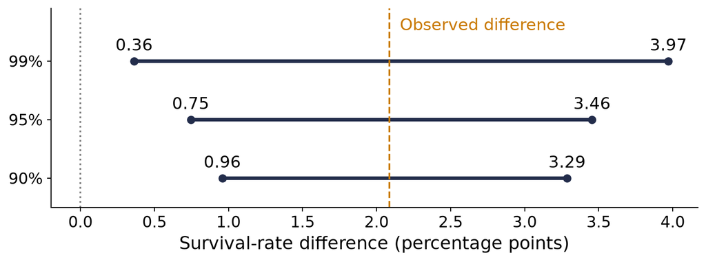

Higher confidence requires a wider interval. All three intervals exclude zero.

## Confidence Intervals and Tests

Is there evidence that the population survival rates differ?

- The **null hypothesis**, $H_0$, says the population rates are equal.
- The **alternative hypothesis**, $H_1$, says the population rates differ.

Our 95% confidence interval for the population difference is **[0.75, 3.46] percentage points**.

- **Zero means equal rates.** It is outside the interval, so we **reject $H_0$**.
- If zero were inside the interval, equal rates would remain plausible: we would **fail to reject $H_0$**.

Using a 95% confidence interval this way is called a two-sided test at the **5% significance level**.

## Example: Balloon Pump Support

A second study compared survival during the first 30 days after coronary artery bypass surgery, with and without preoperative balloon-pump support.

| Balloon-pump support | Survived | Total | Survival rate |
| --- | --- | --- | --- |
| Received support | 60 | 64 | 93.75% |
| Did not receive support | 85 | 92 | 92.39% |

The observed survival rate was **1.36 percentage points higher** with support.

Is there evidence that the population survival rates differ?

## Interval for Balloon-Pump Support

Resample within each group, as in the CPR example. The 95% interval from 5,000 resamples is shown below.

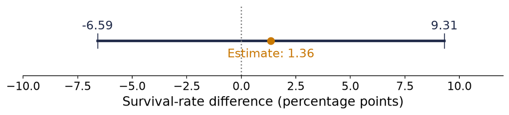

What does this interval tell us about equal population survival rates?

- Zero is inside the interval, so we **fail to reject equal population rates**.
- Differences in either direction remain plausible. Failing to reject does not establish that the rates are equal.

## p-Values

Testing whether the population survival rates are equal:

- **5% significance:** reject equal rates if the **95% confidence interval excludes zero**.
- **1% significance:** require the **wider 99% interval to exclude zero**—a stricter test.

How far can we lower the significance level and still reject equal rates?

- The **p-value** is the smallest significance level at which we still reject equal rates.
- **CPR:** the 99% interval excludes zero, so **$p<0.01$**.
- A **smaller p-value** means stronger evidence against equal rates.

## Example: Bootstrapping a Regression Coefficient

Recall lecture 05’s model of car price and age.

- Each row is one car from the auction listings.
- Age is measured from the newest model year in the data.

```python
cars = pd.read_csv("./src/USA_cars_datasets.csv")
cars["age"] = cars["year"].max() - cars["year"]
cars[["age", "price"]].head(3)
```

|  | age | price |
| --- | --- | --- |
| 0 | 12 | 6300 |
| 1 | 9 | 2899 |
| 2 | 2 | 5350 |

A different sample of cars would give a different fitted line. How much would the **estimated age coefficient** vary?

## Preparing the Car Data

```python
cars["price_ihs"] = np.arcsinh(cars["price"])
cars["age_ihs"] = np.arcsinh(cars["age"])
car_data = cars.loc[
    (cars["price_ihs"] > 9) & (cars["age_ihs"] < 4),
    ["age_ihs", "price_ihs"]
].copy()
print("Retained cars:", len(car_data))
```

```
Retained cars: 2256
```

We will resample these **2,256 cars** and fit the same model each time.

## The Fitted Age Coefficient

Fit transformed price using transformed age:

```python
car_model = LinearRegression().fit(
    car_data[["age_ihs"]], car_data["price_ihs"]
)
print(f"Age coefficient: {car_model.coef_[0]:.3f}")
```

```
Age coefficient: -0.330
```

$$\widehat{\operatorname{asinh}(\text{price})}
=10.963-0.330\,\operatorname{asinh}(\text{age}).$$

The negative coefficient means fitted price decreases with age.

## Resampling Car Records

To create one bootstrap estimate:

1. Draw **2,256 rows with replacement** from `car_data`.
2. Refit the model using those cars’ ages and prices.
3. Save the fitted age coefficient.

## Bootstrapping the Age Coefficient

Repeat the resample-and-refit steps 2,000 times:

```python
rng_car = np.random.default_rng(8005)
car_models = []
for _ in range(2000):
    indices = rng_car.integers(0, len(car_data), size=len(car_data))
    resample = car_data.iloc[indices]
    fit = LinearRegression().fit(resample[["age_ihs"]], resample["price_ihs"])
    car_models.append(fit)
car_slopes = np.array([fit.coef_[0] for fit in car_models])
print("First five coefficients:", car_slopes[:5].round(3))
```

```
First five coefficients: [-0.32  -0.346 -0.331 -0.358 -0.313]
```

- `car_models`: fitted models saved for later predictions.
- `car_slopes`: one age coefficient per resample.

## Interval for the Age Coefficient

```python
car_bounds = np.quantile(car_slopes, [.025, .975])
print("95% interval:", car_bounds.round(3))
```

```
95% interval: [-0.362 -0.297]
```

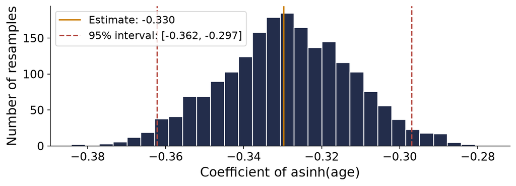

The original fitted coefficient is −0.330. The middle 95% of bootstrap coefficients runs from −0.362 to −0.297.

## Interpreting the Coefficient Interval

For cars meeting our selection rule:

- The coefficient relates **transformed age** to **transformed price**.
- We are **95% confident** that the population age coefficient lies between **−0.362 and −0.297**.

What does this tell us about a population age coefficient of zero?

- The interval lies entirely below zero, so we reject a coefficient of zero at the **5% significance level**.
- The data support a **negative relationship**.

## Uncertainty in Fitted Predictions

- Earlier, we saved an **age coefficient** from each fitted model.
- Now consider the **prediction at age 5**: the line’s estimate of average transformed price.

Using the original fitted model:

```python
age_five_input = pd.DataFrame({"age_ihs": [np.arcsinh(5)]})
age_five_prediction = car_model.predict(age_five_input)[0]
print(f"Prediction at age 5: {age_five_prediction:.2f}")
```

```
Prediction at age 5: 10.20
```

How much would the age-5 prediction change if we had observed a different sample of cars?

## Bootstrapping the Age-5 Prediction

Use each of the **2,000 saved models** to predict at **age 5**:

```python
age_five_predictions = np.array([
    fit.predict(age_five_input)[0] for fit in car_models
])
print("First five predictions:", age_five_predictions[:5].round(3))
```

```
First five predictions: [10.225 10.177 10.216 10.171 10.212]
```

- The prediction age stays fixed at **5**.
- The fitted models differ because each model used a different resample of cars.
- Variation across the predictions estimates **sampling uncertainty** in the age-5 prediction.

## Interval for the Age-5 Prediction

Take the 2.5th and 97.5th percentiles of the **2,000 age-5 predictions**:

```python
age_five_bounds = np.quantile(age_five_predictions, [.025, .975])
print("95% interval:", age_five_bounds.round(2))
```

```
95% interval: [10.16 10.24]
```

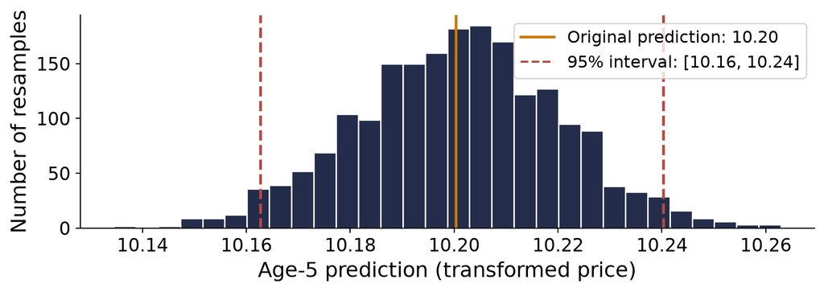

For cars meeting our selection rule, we are 95% confident that the population line’s average transformed price at age 5 lies between 10.16 and 10.24.

## What Does the Interval Describe?

Does **[10.16, 10.24]** contain 95% of individual transformed prices at age 5?

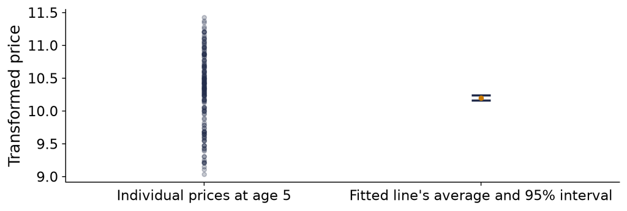

- **No.** The interval is for the population line’s **average transformed price** at age 5.
- Individual transformed prices can be **far from the line’s average**.

## Resampling and Ensembles

What can we do with the 2,000 predictions at age 5?

- The **spread** of the predictions helps estimate sampling uncertainty.
- **Averaging the predictions** gives one combined prediction.
- An **ensemble** combines predictions from several models.

## Limits of Resampling

- **Sample quality:** resampling cannot fix a sample that poorly represents the population.
- **Small samples:** more resamples cannot make up for too few observed data points.

## Summary

- Sample means, fitted coefficients, and predictions can change with the sample.
- The bootstrap estimates this variation by resampling the observed data **with replacement** and repeating the analysis.
- Bootstrap percentiles give confidence intervals. These intervals can also test a hypothesized value.
- For uncertainty in fitted predictions, compare predictions at the **same input** across resampled fits.